# a quick look at the salem library

[Salem](https://github.com/fmaussion/salem) is a python library developed by [Fabien Maussion](http://fabienmaussion.info/), a researcher and lecturer at the Institute of Atmospheric and Cryospheric Sciences, at the University of Innsbruck.

It extends [xarray](http://xarray.pydata.org/en/stable/) and adds notably geolocalised subsetting (via shapefiles), masking, and geographical mapping operations to xarray’s [DataArray](http://xarray.pydata.org/en/stable/data-structures.html#dataarray) [DataSet](http://xarray.pydata.org/en/stable/data-structures.html#) datasetdata structures.

It is still ayoung project, but has already proven extremely useful to me in a number of occasions, and I think it's the perfect illustration of how one can build clever and useful extensions build on the very powerful [xarray](http://xarray.pydata.org/en/stable/) data structures. I hope to be able to contribute to this project, and this post is intended to be a shoutout and acknowledgment of [Fabien Maussion](http://fabienmaussion.info/)'s work.

If you work in climate / ocean science and are already using (as you should !) xarray, [Salem](https://github.com/fmaussion/salem) is definitely worth a try

### installation

[Salem](https://github.com/fmaussion/salem) has a number of hard dependencies: what worked for me (*MacOS Sierra*) is to create a specific environment following the instructions available [here](https://github.com/ioos/notebooks_demos/wiki/Installing-Conda-Python-with-the-IOOS-environment), then installing **Salem** in this environment using pip and development version of Salem, via:

````
    ```
    pip install git+https://github.com/fmaussion/salem.git
    ```
````

```python
%matplotlib inline
```

```python
from matplotlib import pyplot as plt
```

```python
import numpy as np
import xarray as xr
```

```python
import salem

from salem.utils import get_demo_file

ds = salem.open_xr_dataset(get_demo_file('wrfout_d01.nc'))
```

```python
t2 = ds.T2.isel(Time=2)
```

```python
shdf = salem.read_shapefile(get_demo_file('world_borders.shp'))
```

```
<salem.graphics.Map at 0x119187a58>
```

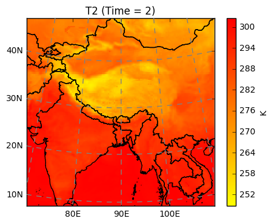

```python
t2.salem.quick_map(cmap=plt.cm.autumn_r)
```